# Final Project

## Data Visdualization on Madarin Vowels

## Introduction

- Mandarin Chinese has a five-vowel system
1. [yi], [yu], [wu], [en] and [ai]
2. Four allophones for the **mid vovel**: [e], [o], [en] and [e]
3. Two allophones for the **low vovel**: [ai] and [ao]

## Research Gap

- What are the individual variances when producing these 9 vowels?
- Vowel space in Chinese?

## Current Study

This study investigates **native Chinese speakers'** vowel distribution and **non-native Chinese speakers'** vowel distribution

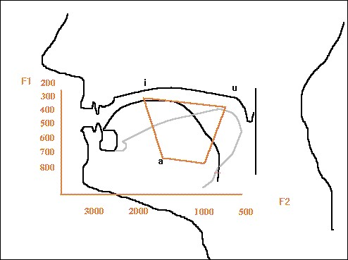

vocal tract

## Methods

### Participants

- 6 female native Mandarin speakers (NS) & 6 female non-native Mandarin speakers (NNS)
- Average age
1. NS Mandarin speakers was 26.3 (range: 23-30)
2. NNS Mandarin speakers was 22.3 (range: 18-28)
- Length of study: 6 months

## Methods

### Speech materials

- 9 Chinese sentences
- Each sentence includes one of the following nine vowels: [yi], [yu], [wu], [e], [o], [en], [e], [ai], [ao].
- Each vowel appears after the aspirated bilabial stop [p] with a high tone (55).

## Methods

### Procedure

- Sentence-repetition oral task
- Non-native speakers and native Chinese speakers were asked to read the sentences twice.
- Formant 1 (F1) and Formant 2 (F2) were measured in the vowel mid-point for each vowel shown in the spectrogram through Praat.

## Teresa's R Journey

## Looking at Our Data

```
## # A tibble: 6 x 14
##   X__1  gender height   age Mean     yi    yu    wu    ye    wo    en     e
##   <chr> <chr>   <dbl> <dbl> <chr> <dbl> <dbl> <dbl> <dbl> <dbl> <dbl> <dbl>
## 1 NS1   F         163    29 F1      270   326   320   583   553   730   634
## 2 NS1   F         163    29 F2     3041  2678   927  2548   872  1803  1078
## 3 NS2   F         164    30 F1      321   307   341   537   563   710   482
## 4 NS2   F         164    30 F2     2909  2383   836  2347   958  1863  1201
## 5 NS3   F         165    27 F1      300   316   321   547   472   740   553
## 6 NS3   F         165    27 F2     2899  2481   776  2694   821  1812  1282
## # ... with 2 more variables: ai <dbl>, ao <dbl>
```

- Data is definitely NOT tidy!
  - Variables (F1, F2) don't have thier own columns.
  - Each row includes multiple observations from multiple vowels.
- Confidence level: 5/5 with `dplyr::spread` and `dplyr::gather`

## What else? (1)

```r
names(df)
```

```
##  [1] "X__1"   "gender" "height" "age"    "Mean"   "yi"     "yu"
##  [8] "wu"     "ye"     "wo"     "en"     "e"      "ai"     "ao"
```

- Varibles' name are not clean.
  - Confidence level: 5/5 with `janitor::clean_names`

## What else? (2)

```r
print(df$X__1)
```

```
##  [1] "NS1"  "NS1"  "NS2"  "NS2"  "NS3"  "NS3"  "NS4"  "NS4"  "NS5"  "NS5"
## [11] "NS6"  "NS6"  "NNS1" "NNS1" "NNS2" "NNS2" "NNS3" "NNS3" "NNS4" "NNS4"
## [21] "NNS5" "NNS5" "NNS6" "NNS6"
```

- X__1 contains **id** and **group** (NS & NNS).
  - Confidence level: 2/5 with `dplyr::separate`
    - sep = ?
- Duplicate id number for NS and NNS
  - Confidence level: 0/5
    - use `dplyr::case_when` ?

## Tidy data step 1: fix x__1

```r
tidy_df1 <- df %>%
  clean_names(case = "snake") %>%
  separate(x_1, into = c("group", "id"),
           sep = "(?<=[A-Za-z])(?=[0-9])") %>%  #sep = -1 also works
  mutate(id = case_when(
   group == "NNS" & id == '1' ~  '7',
   group == "NNS" & id == '2' ~  '8',
   group == "NNS" & id == '3' ~  '9',
   group == "NNS" & id == '4' ~  '10',
   group == "NNS" & id == '5' ~  '11',
   group == "NNS" & id == '6' ~  '12',
   TRUE ~ id
   )) %>%
  mutate(group = as.factor(group),
        id = as.numeric(id))
```

```r
head(df, n = 3)
```

```
## # A tibble: 3 x 14
##   X__1  gender height   age Mean     yi    yu    wu    ye    wo    en     e
##   <chr> <chr>   <dbl> <dbl> <chr> <dbl> <dbl> <dbl> <dbl> <dbl> <dbl> <dbl>
## 1 NS1   F         163    29 F1      270   326   320   583   553   730   634
## 2 NS1   F         163    29 F2     3041  2678   927  2548   872  1803  1078
## 3 NS2   F         164    30 F1      321   307   341   537   563   710   482
## # ... with 2 more variables: ai <dbl>, ao <dbl>
```

```r
head(tidy_df1, n = 3)
```

```
## # A tibble: 3 x 15
##   group    id gender height   age mean     yi    yu    wu    ye    wo    en
##   <fct> <dbl> <chr>   <dbl> <dbl> <chr> <dbl> <dbl> <dbl> <dbl> <dbl> <dbl>
## 1 NS        1 F         163    29 F1      270   326   320   583   553   730
## 2 NS        1 F         163    29 F2     3041  2678   927  2548   872  1803
## 3 NS        2 F         164    30 F1      321   307   341   537   563   710
## # ... with 3 more variables: e <dbl>, ai <dbl>, ao <dbl>
```

## Tidy data step 2: gather

```r
tidy_df2 <- tidy_df1 %>%
  gather(vowel, value, -1:-6) %>%
  mutate(vowel = as.factor(vowel))

head(tidy_df2)
```

```
## # A tibble: 6 x 8
##   group    id gender height   age mean  vowel value
##   <fct> <dbl> <chr>   <dbl> <dbl> <chr> <fct> <dbl>
## 1 NS        1 F         163    29 F1    yi      270
## 2 NS        1 F         163    29 F2    yi     3041
## 3 NS        2 F         164    30 F1    yi      321
## 4 NS        2 F         164    30 F2    yi     2909
## 5 NS        3 F         165    27 F1    yi      300
## 6 NS        3 F         165    27 F2    yi     2899
```

## Tidy data step 3: spread

```r
tidy_df <- tidy_df2 %>%
  spread(mean, value) %>%
  #reorder variables & discard gender
  select(id, group, age, height, vowel, F1, F2) %>%
  arrange(id)

head(tidy_df)
```

```
## # A tibble: 6 x 7
##      id group   age height vowel    F1    F2
##   <dbl> <fct> <dbl>  <dbl> <fct> <dbl> <dbl>
## 1     1 NS       29    163 ai      808  1802
## 2     1 NS       29    163 ao      832  1531
## 3     1 NS       29    163 e       634  1078
## 4     1 NS       29    163 en      730  1803
## 5     1 NS       29    163 wo      553   872
## 6     1 NS       29    163 wu      320   927
```

## Plot Data Like This

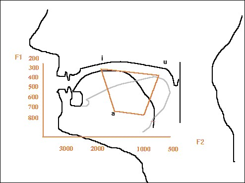

vocal tract

- Raw Data (data points from each individual)
- Group Data (mean values from each group)

## Code for Figure 1 (for Raw Data)

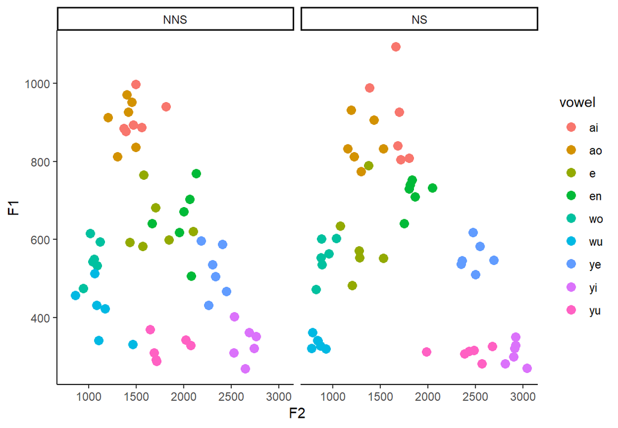

```r
figure1_pre <- tidy_df %>%
  ggplot(aes(x = F2, y = F1, color = vowel)) +
  geom_point(size = 3) +
  facet_wrap(~ group) +
  theme_classic()
```

- Couple issues:
  - X and Y axes need to be rotated.
  - Labels are not in a conventional order.

## Refined Code for Figure 1

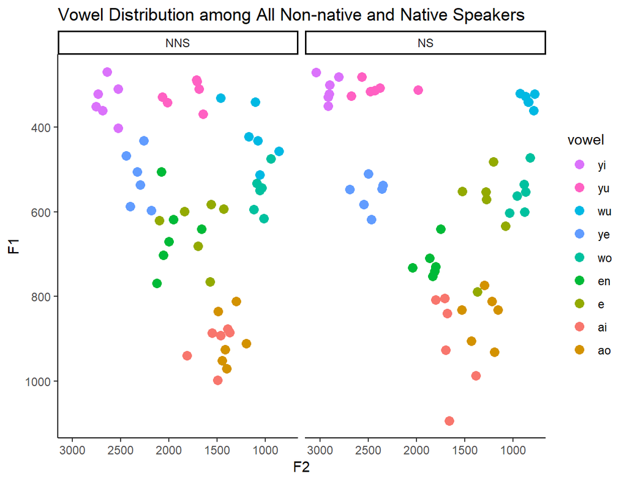

```r
figure1_post <- tidy_df %>%
  ggplot(aes(x = F2, y = F1, color = vowel)) +
  geom_point(size = 3) +
  facet_wrap(~ group) +
  theme_classic() +

  #reverse x and y to meet the perception of sounds
  scale_x_reverse() +
  scale_y_reverse() +

  #reorder vowel based on IPA order
  scale_color_discrete(breaks = c("yi", "yu",
                                  "wu", "ye",
                                  "wo", "en",
                                  "e", "ai",
                                  "ao")) +
  labs(title = "Vowel Distribution among All Non-native and Native Speakers")
```

- Inefficient references due to 9 vowels.

[figure not shown]

[figure not shown]

## Acknowledge

- Google
- Special Thank You to Joey Stanley !
  - [Joey's blog](http://joeystanley.com/blog/making-vowel-plots-in-r-part-1)
  - Making vowel plots in R

## Code for Figure 2 (for Group Mean)

```r
smry_df <- tidy_df %>%
  group_by(group, vowel) %>%
  summarize_at(vars(F1, F2), funs(mean, sd))


figure2 <- smry_df %>%
  ggplot(aes(x = F2_mean, y = F1_mean)) +

    # adds text directly to the plot
    geom_label(aes(label = vowel, color = group)) +

    scale_x_reverse() +
    scale_y_reverse() +
    theme_classic() +
    labs(title = "Mean Vowel Distribution between Non-native and Native Speakers",
         x = "F2",
         y = "F1")
```

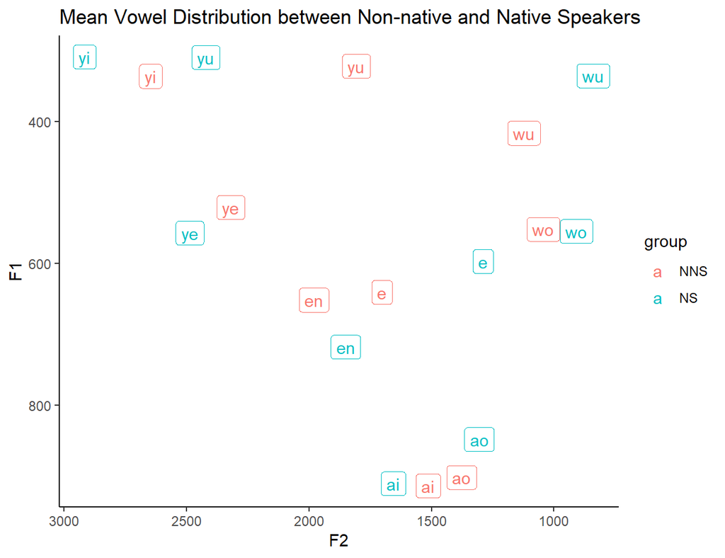

```r
figure2
```

## More to Explore !

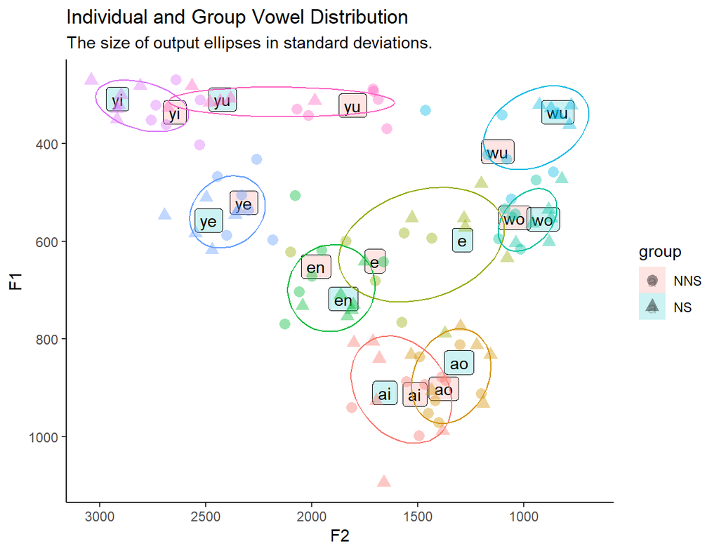

```r
figure3 <-
  ggplot(data = tidy_df, aes(x = F2, y = F1 )) +
  geom_label(data = smry_df, aes(x = F2_mean, y = F1_mean,
                                 label = vowel, fill = group),
             alpha = 0.2) +
  geom_point(aes(color = vowel, shape = group),
             size = 3, alpha = 0.4) +
  stat_ellipse(aes(color = vowel), level = 0.67) +
  scale_x_reverse() +
  scale_y_reverse() +
  theme_classic() +
  labs(title = "Individual and Group Vowel Distribution",
       subtitle = "The size of output ellipses in standard deviations.") +
  guides(color = FALSE)
```

## Jun's Journey

## Jun's frustration: Table

```r
smry_df %>%
  kable(format = "html",digits = 2,caption = "Table1",booktabs = T)
```

Table1

| group | vowel | F1_mean | F2_mean | F1_sd | F2_sd |
| --- | --- | --- | --- | --- | --- |
| NNS | ai | 913.33 | 1513.83 | 47.14 | 161.28 |
| NNS | ao | 901.50 | 1377.00 | 63.86 | 107.69 |
| NNS | e | 640.33 | 1702.33 | 70.43 | 238.62 |
| NNS | en | 651.33 | 1980.00 | 88.59 | 166.70 |
| NNS | wo | 551.50 | 1043.67 | 49.79 | 61.90 |
| NNS | wu | 416.00 | 1122.83 | 69.62 | 196.96 |
| NNS | ye | 520.67 | 2320.00 | 65.50 | 95.07 |
| NNS | yi | 335.67 | 2646.50 | 46.03 | 100.61 |
| NNS | yu | 321.50 | 1806.83 | 31.25 | 186.00 |
| NS | ai | 910.33 | 1655.50 | 115.38 | 142.20 |
| NS | ao | 848.00 | 1305.17 | 59.50 | 147.96 |
| NS | e | 596.83 | 1289.67 | 105.92 | 152.62 |
| NS | en | 717.67 | 1850.50 | 40.10 | 101.96 |
| NS | wo | 554.50 | 908.67 | 48.53 | 76.63 |
| NS | wu | 335.00 | 840.00 | 15.63 | 56.02 |
| NS | ye | 556.83 | 2486.50 | 38.02 | 128.39 |
| NS | yi | 308.33 | 2916.17 | 30.23 | 73.78 |
| NS | yu | 309.17 | 2420.83 | 15.17 | 237.25 |

```r
kable(smry_df)
```

| group | vowel | F1_mean | F2_mean | F1_sd | F2_sd |
| --- | --- | --- | --- | --- | --- |
| NNS | ai | 913.3333 | 1513.8333 | 47.13668 | 161.27544 |
| NNS | ao | 901.5000 | 1377.0000 | 63.86157 | 107.68658 |
| NNS | e | 640.3333 | 1702.3333 | 70.43484 | 238.62411 |
| NNS | en | 651.3333 | 1980.0000 | 88.59044 | 166.69973 |
| NNS | wo | 551.5000 | 1043.6667 | 49.78654 | 61.89884 |
| NNS | wu | 416.0000 | 1122.8333 | 69.61609 | 196.95930 |
| NNS | ye | 520.6667 | 2320.0000 | 65.49707 | 95.07471 |
| NNS | yi | 335.6667 | 2646.5000 | 46.03332 | 100.60765 |
| NNS | yu | 321.5000 | 1806.8333 | 31.24580 | 186.00367 |
| NS | ai | 910.3333 | 1655.5000 | 115.37533 | 142.20373 |
| NS | ao | 848.0000 | 1305.1667 | 59.50462 | 147.96272 |
| NS | e | 596.8333 | 1289.6667 | 105.91962 | 152.62066 |
| NS | en | 717.6667 | 1850.5000 | 40.10320 | 101.96225 |
| NS | wo | 554.5000 | 908.6667 | 48.52937 | 76.62550 |
| NS | wu | 335.0000 | 840.0000 | 15.63330 | 56.02142 |
| NS | ye | 556.8333 | 2486.5000 | 38.01798 | 128.39120 |
| NS | yi | 308.3333 | 2916.1667 | 30.23023 | 73.77917 |
| NS | yu | 309.1667 | 2420.8333 | 15.17124 | 237.25212 |

## Spread: F1 mean

```r
table_f1mean <- smry_df %>%
  select(1:3) %>%
  spread(vowel,F1_mean)

table_f1mean
```

```
## # A tibble: 2 x 10
## # Groups:   group [2]
##   group    ai    ao     e    en    wo    wu    ye    yi    yu
##   <fct> <dbl> <dbl> <dbl> <dbl> <dbl> <dbl> <dbl> <dbl> <dbl>
## 1 NNS    913.  902.  640.  651.  552.   416  521.  336.  322.
## 2 NS     910.  848   597.  718.  554.   335  557.  308.  309.
```

## Spread: F2 mean

```r
table_f2mean <- smry_df %>%
  select(1:2,4) %>%
  spread(vowel,F2_mean)

table_f2mean
```

```
## # A tibble: 2 x 10
## # Groups:   group [2]
##   group    ai    ao     e    en    wo    wu    ye    yi    yu
##   <fct> <dbl> <dbl> <dbl> <dbl> <dbl> <dbl> <dbl> <dbl> <dbl>
## 1 NNS   1514. 1377  1702. 1980  1044. 1123. 2320  2646. 1807.
## 2 NS    1656. 1305. 1290. 1850.  909.  840  2486. 2916. 2421.
```

## New fuction: bind_rows

```r
bind_rows(table_f1mean,table_f2mean) -> bindtables
bindtables
```

```
## # A tibble: 4 x 10
## # Groups:   group [2]
##   group    ai    ao     e    en    wo    wu    ye    yi    yu
##   <fct> <dbl> <dbl> <dbl> <dbl> <dbl> <dbl> <dbl> <dbl> <dbl>
## 1 NNS    913.  902.  640.  651.  552.  416   521.  336.  322.
## 2 NS     910.  848   597.  718.  554.  335   557.  308.  309.
## 3 NNS   1514. 1377  1702. 1980  1044. 1123. 2320  2646. 1807.
## 4 NS    1656. 1305. 1290. 1850.  909.  840  2486. 2916. 2421.
```

## New: add a column and rename the items in this column

```r
bindtables["Mean"] <- c("F1","","F2","")
bindtables
```

```
## # A tibble: 4 x 11
## # Groups:   group [2]
##   group    ai    ao     e    en    wo    wu    ye    yi    yu Mean
##   <fct> <dbl> <dbl> <dbl> <dbl> <dbl> <dbl> <dbl> <dbl> <dbl> <chr>
## 1 NNS    913.  902.  640.  651.  552.  416   521.  336.  322. F1
## 2 NS     910.  848   597.  718.  554.  335   557.  308.  309. ""
## 3 NNS   1514. 1377  1702. 1980  1044. 1123. 2320  2646. 1807. F2
## 4 NS    1656. 1305. 1290. 1850.  909.  840  2486. 2916. 2421. ""
```

## New: move the column to the front

```r
bindtables_new <- bindtables[colnames(bindtables)[c(11,1:10)]]
bindtables_new
```

```
## # A tibble: 4 x 11
## # Groups:   group [2]
##   Mean  group    ai    ao     e    en    wo    wu    ye    yi    yu
##   <chr> <fct> <dbl> <dbl> <dbl> <dbl> <dbl> <dbl> <dbl> <dbl> <dbl>
## 1 F1    NNS    913.  902.  640.  651.  552.  416   521.  336.  322.
## 2 ""    NS     910.  848   597.  718.  554.  335   557.  308.  309.
## 3 F2    NNS   1514. 1377  1702. 1980  1044. 1123. 2320  2646. 1807.
## 4 ""    NS    1656. 1305. 1290. 1850.  909.  840  2486. 2916. 2421.
```

## Yay! A better table!

```r
bindtables_new %>%
  kable(format = "html",digits = 2,caption = "Table 1", booktabs = T)
```

Table 1

| Mean | group | ai | ao | e | en | wo | wu | ye | yi | yu |
| --- | --- | --- | --- | --- | --- | --- | --- | --- | --- | --- |
| F1 | NNS | 913.33 | 901.50 | 640.33 | 651.33 | 551.50 | 416.00 | 520.67 | 335.67 | 321.50 |
|  | NS | 910.33 | 848.00 | 596.83 | 717.67 | 554.50 | 335.00 | 556.83 | 308.33 | 309.17 |
| F2 | NNS | 1513.83 | 1377.00 | 1702.33 | 1980.00 | 1043.67 | 1122.83 | 2320.00 | 2646.50 | 1806.83 |
|  | NS | 1655.50 | 1305.17 | 1289.67 | 1850.50 | 908.67 | 840.00 | 2486.50 | 2916.17 | 2420.83 |

## Challenges we are still facing: M (SD)

[figure not shown]

An ideal table